# Lab 8 Espacio Producto

Cony

2025-10-02

Hecho con gusto por Maria Concepcion García Pérez

LABORATORIO - RELACIONAMIENTO “CASO HIPOTÉTICO”

Objetivo: Estimar el relacionamiento (relatedness, proximidad, métrica de distancia entre productos)

En este ejercicio vamos a: 1. Cargar nuestra matriz hipotética de datos 2. Calcular co ocurrencias entre personas y productos 3. Estimar el relacionamiento, teniendo como input las co ocurrencias 4. Graficar

Cargar paqueterias necesarias install.packages(“EconGeo”)

```r
library (EconGeo)
```

```
##  Balland, P.A. (2017) Economic Geography in R: Introduction to the EconGeo Package, Papers in Evolutionary Economic Geography, 17 (09): 1-75
```

1.Cómo se mide la proximidad (relatedness) para crear el espacio producto Material: Balland, P.A. (2017) Economic Geography in R: Introduction to the EconGeo Package, Papers in Evolutionary Economic Geography, 17 (09): 1-75 Para instalar: https://www.paballand.com/install-r

Llamar a la matriz hipotetica

```r
M = as.matrix(
  read.csv("https://raw.githubusercontent.com/PABalland/ON/master/amz.csv" ,
           sep = ",",
           header = T,
           row.names = 1))

M
```

```
##        Tie Book Surfboard Short Water
## Pierre   0    0         1     1     1
## Ron      1    1         0     0     1
## Andrea   1    1         0     0     1
## David    0    0         1     1     1
## Cesar    1    1         0     0     1
## Paula    1    1         1     1     1
```

co-ocurrencia entre personas/paises/estados

```r
C <- co_occurrence(M, list = FALSE)
c
```

[output not shown]

```
## function (...)  .Primitive("c")
```

co-ocurrencia entre productos t es transpuesta

```r
Ct <- co_occurrence(t(M), list = FALSE)

Ct
```

```
##           Tie Book Surfboard Short Water
## Tie         0    4         1     1     4
## Book        4    0         1     1     4
## Surfboard   1    1         0     3     3
## Short       1    1         3     0     3
## Water       4    4         3     3     0
```

estima el relacionamiento o proximidad pero normalizado, para asegurar que el numero de co ocurrencias que observamos

```r
r <- relatedness(Ct)
```

es mayor al numero de co ocurrencias probables (probailidad condicional) tie and Surfboard puede que no esten tan relacionados, abajo de 1 no es relacionado mientras que mayor a 1 si es relacionado

```r
r[r<1] =0
r[r>1] =1
```

Llamar a la grafica

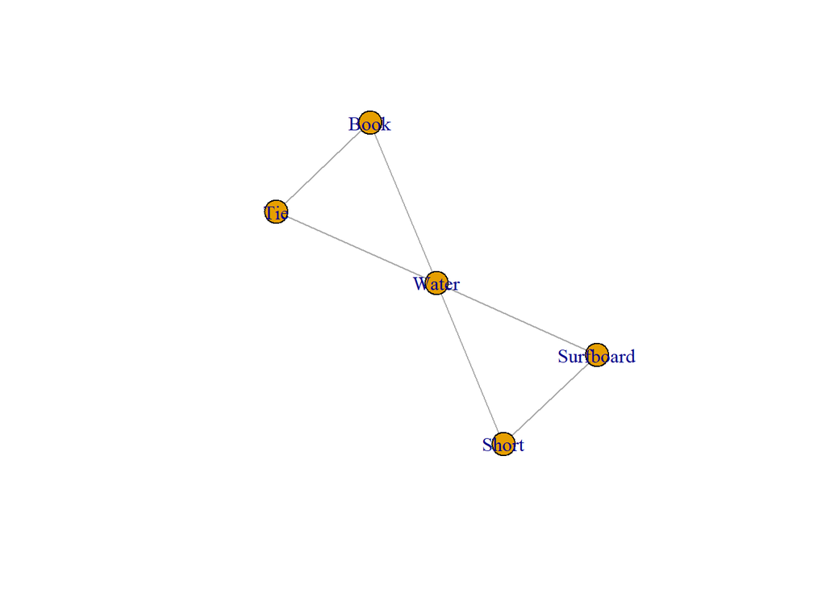

```r
library (igraph)
g1=graph_from_adjacency_matrix(r,mode = "undirected")
plot(g1)
```